# Indian House Marketing Analysis

Jeyakumar N K

31/12/2023

#### **Beyond Price Tags: Understanding What Makes Buyers Jump Through Hoops**

### 1. Introduction

Imagine trying to find the perfect home in the bustling Indian market. It’s exciting, but with so many choices, where do you even start? Developers want to know what makes you pass out over a property, investors want to find the next hot locality, and you, the home buyer, just want to feel confident in your choice. This case study is like a trusty map, helping us understand what makes buyers like you tick. It will uncover the hidden forces that drive decisions, empowering developers to build your dream homes, investors to make smart choices, and you, the buyer, to find the perfect place to call your own. This study delves through six phases of Data Analysis as from Ask, Prepare, Process, Analyse, Share, Act. So, sit tight and let’s explore the exciting world of Indian house marketing!

### 2. Ask

This phase involves asking questions to make data driven decisions.

**What is the Problem?** Many stakeholders in the Indian housing market lack a deep understanding of what drives buyers to purchase specific properties. This leads to ineffective marketing strategies and listing prioritization, potentially impacting sales and profitability.

**How it can be solved?** Identifying factors influencing buyer decisions in the Indian housing market, with a focus on location, price, property features, and other influential aspects.

**Identifying Metrics for achieving objective**

- *Price per Square Foot:* To analyse how price varies across different locations, property types, and features to understand buyer preferences and value perceptions.
- *Geographical Patterns:* To explore how property prices, sales volume, and buyer preferences vary across different cities to identify popular areas and potential market shifts.
- *Property Feature Preferences:* To analyse which features (e.g., number of bedrooms, square footage, amenities) are associated with higher sale prices or faster sales to understand buyer priorities.

**Who are all the Stakeholders?**

- *Developers:* Can refine target audiences, optimize project features, and adjust pricing strategies based on buyer preferences.
- *Real Estate Agents:* Can hone marketing efforts, prioritize listings based on buyer interest, and provide better property recommendations.
- *Investors:* Can identify promising locations, property types, and features for optimal investment returns.

**Who is the audience for this analysis?**

- *Primary audience:* Stakeholders mentioned above, with varying levels of data expertise.
- *Secondary audience:* Potential home buyers interested in market trends and insights.

**How will this data help stakeholders make decisions?**

This data analysis will empower stakeholders to:

- Prioritize features and amenities in listings based on buyer preferences and market trends.
- Optimize pricing strategies to find the sweet spot between profitability and buyer attraction.
- Identify promising locations for new housing projects based on demand and market dynamics.
- Make informed investment decisions in the Indian housing market.

### 3. Prepare

**Data Collection and Storing:**

The data is currently located in a table format, within a spreadsheet. The data is organized into rows representing individual properties and columns representing their attributes (e.g., location, price, features).

**Data Credibility (ROCCC):**

- **R**eliable: The data used for this analysis was from Kaggle, which is the world’s largest reputable data science community with powerful resources for achieving data science goals.
- **O**riginal: Since the data was collected from property aggregators directly, no compromisation to its integrity.
- **C**omprehensive: It was mentioned on Kaggle’s site that “the dataset has been collected across various property aggregators in India.” So, it will cover a representative sample of the Indian housing market
- **C**urrent: Even though the dataset used for this analysis is not current (meant for study purposes), it still reflects recent trends as it is not very old.
- **C**ited: My insights on buyer decisions in the Indian housing market are based on data gathered from the Kaggle **[House Price Dataset](https://www.kaggle.com/datasets/akash14/house-price-dataset/data)**

**Data Integrity Verification:**

Initially, the data was loaded in Excel for checking consistency, completeness and accuracy. That includes data formatting, removing duplicated entries, data filtering and sorting.

**Attributes Description:**

POSTED_BY - Category marking who has listed the property like owner, dealer or builder

UNDER_CONSTRUCTION - Under Construction or Not in form of 1’s and 0’s respectively

RERA - Rera approved or Not in form of 1’s and 0’s respectively

BHK_NO - Number of Rooms

BHK_OR_RK - Type of property. Bedroom + Hall + Kitchen or Room + Kitchen

SQUARE_FT - Total area of the house in square feet

READY_TO_MOVE - Category marking Ready to move or Not in form of 1’s and 0’s respectively

RESALE - Category marking Resale or not in form of 1’s and 0’s respectively

ADDRESS - Address of the property

LONGITUDE - Longitude of the property

LATITUDE - Latitude of the property

TARGET – Price of the property being sold in lakhs

### 4. Process

**Tools:**

- **R**: Chosen for its statistical capabilities, extensive data manipulation packages, and wide-ranging visualization options, making it well-suited for this analysis.

Specific R packages used:

1. *tidyverse* for data cleaning and manipulation.
2. *dplyr* for data transformation.
3. *ggplot2* for data visualization.

**Installing Packages:** Installed all the required packages for analysis using install.packages(). Here is a complete snapshot of all installed packages.

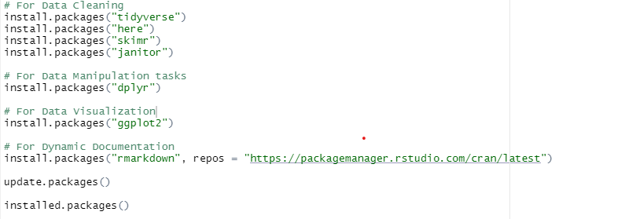

**Importing data:** Loaded the data set into R using read_csv() function.

```r
library(readr)
data_set <- read_csv('C:\\Users\\ELCOT\\Desktop\\Data Science\\Data Analytics\\GDA Capstone Project\\House Marketting Dataset.csv')
```

**Data exploration:** Examined the data structure using str() and summary() to visualize data types and distributions.

```r
library(tidyverse)
colnames(data_set) # Column names of data set
```

```
##  [1] "POSTED_BY"             "UNDER_CONSTRUCTION"    "RERA"
##  [4] "BHK_NO."               "BHK_OR_RK"             "SQUARE_FT"
##  [7] "READY_TO_MOVE"         "RESALE"                "ADDRESS"
## [10] "LONGITUDE"             "LATITUDE"              "TARGET(PRICE_IN_LACS)"
```

```r
str(data_set) #Structure of data set
```

```
## spc_tbl_ [29,451 x 12] (S3: spec_tbl_df/tbl_df/tbl/data.frame)
##  $ POSTED_BY            : chr [1:29451] "Owner" "Dealer" "Owner" "Owner" ...
##  $ UNDER_CONSTRUCTION   : num [1:29451] 0 0 0 0 1 0 0 0 0 0 ...
##  $ RERA                 : num [1:29451] 0 0 0 1 0 0 0 1 1 1 ...
##  $ BHK_NO.              : num [1:29451] 2 2 2 2 2 3 3 3 2 2 ...
##  $ BHK_OR_RK            : chr [1:29451] "BHK" "BHK" "BHK" "BHK" ...
##  $ SQUARE_FT            : num [1:29451] 1300 1275 933 930 999 ...
##  $ READY_TO_MOVE        : num [1:29451] 1 1 1 1 0 1 1 1 1 1 ...
##  $ RESALE               : num [1:29451] 1 1 1 1 1 1 1 1 1 1 ...
##  $ ADDRESS              : chr [1:29451] "Ksfc Layout,Bangalore" "Vishweshwara Nagar,Mysore" "Jigani,Bangalore" "Sector-1 Vaishali,Ghaziabad" ...
##  $ LONGITUDE            : num [1:29451] 13 12.3 12.8 28.6 22.6 ...
##  $ LATITUDE             : num [1:29451] 77.6 76.6 77.6 77.3 88.5 ...
##  $ TARGET(PRICE_IN_LACS): num [1:29451] 55 51 43 62.5 60.5 42 66.5 52 41.6 36 ...
##  - attr(*, "spec")=
##   .. cols(
##   ..   POSTED_BY = col_character(),
##   ..   UNDER_CONSTRUCTION = col_double(),
##   ..   RERA = col_double(),
##   ..   BHK_NO. = col_double(),
##   ..   BHK_OR_RK = col_character(),
##   ..   SQUARE_FT = col_double(),
##   ..   READY_TO_MOVE = col_double(),
##   ..   RESALE = col_double(),
##   ..   ADDRESS = col_character(),
##   ..   LONGITUDE = col_double(),
##   ..   LATITUDE = col_double(),
##   ..   `TARGET(PRICE_IN_LACS)` = col_double()
##   .. )
##  - attr(*, "problems")=<externalptr>
```

```r
glimpse(data_set)
```

```
## Rows: 29,451
## Columns: 12
## $ POSTED_BY               <chr> "Owner", "Dealer", "Owner", "Owner", "Dealer",~
## $ UNDER_CONSTRUCTION      <dbl> 0, 0, 0, 0, 1, 0, 0, 0, 0, 0, 0, 0, 0, 0, 0, 1~
## $ RERA                    <dbl> 0, 0, 0, 1, 0, 0, 0, 1, 1, 1, 0, 0, 0, 1, 0, 1~
## $ BHK_NO.                 <dbl> 2, 2, 2, 2, 2, 3, 3, 3, 2, 2, 3, 2, 2, 2, 1, 3~
## $ BHK_OR_RK               <chr> "BHK", "BHK", "BHK", "BHK", "BHK", "BHK", "BHK~
## $ SQUARE_FT               <dbl> 1300.2364, 1275.0000, 933.1597, 929.9211, 999.~
## $ READY_TO_MOVE           <dbl> 1, 1, 1, 1, 0, 1, 1, 1, 1, 1, 1, 1, 1, 1, 1, 0~
## $ RESALE                  <dbl> 1, 1, 1, 1, 1, 1, 1, 1, 1, 1, 1, 1, 1, 1, 1, 1~
## $ ADDRESS                 <chr> "Ksfc Layout,Bangalore", "Vishweshwara Nagar,M~
## $ LONGITUDE               <dbl> 12.96991, 12.27454, 12.77803, 28.64230, 22.592~
## $ LATITUDE                <dbl> 77.59796, 76.64460, 77.63219, 77.34450, 88.484~
## $ `TARGET(PRICE_IN_LACS)` <dbl> 55.0, 51.0, 43.0, 62.5, 60.5, 42.0, 66.5, 52.0~
```

```r
head(data_set)
```

```
## # A tibble: 6 x 12
##   POSTED_BY UNDER_CONSTRUCTION  RERA BHK_NO. BHK_OR_RK SQUARE_FT READY_TO_MOVE
##   <chr>                  <dbl> <dbl>   <dbl> <chr>         <dbl>         <dbl>
## 1 Owner                      0     0       2 BHK           1300.             1
## 2 Dealer                     0     0       2 BHK           1275              1
## 3 Owner                      0     0       2 BHK            933.             1
## 4 Owner                      0     1       2 BHK            930.             1
## 5 Dealer                     1     0       2 BHK            999.             0
## 6 Owner                      0     0       3 BHK           1250              1
## # i 5 more variables: RESALE <dbl>, ADDRESS <chr>, LONGITUDE <dbl>,
## #   LATITUDE <dbl>, `TARGET(PRICE_IN_LACS)` <dbl>
```

```r
summary(data_set)
```

```
##   POSTED_BY         UNDER_CONSTRUCTION      RERA           BHK_NO.
##  Length:29451       Min.   :0.0000     Min.   :0.0000   Min.   : 1.000
##  Class :character   1st Qu.:0.0000     1st Qu.:0.0000   1st Qu.: 2.000
##  Mode  :character   Median :0.0000     Median :0.0000   Median : 2.000
##                     Mean   :0.1798     Mean   :0.3179   Mean   : 2.392
##                     3rd Qu.:0.0000     3rd Qu.:1.0000   3rd Qu.: 3.000
##                     Max.   :1.0000     Max.   :1.0000   Max.   :20.000
##   BHK_OR_RK           SQUARE_FT         READY_TO_MOVE        RESALE
##  Length:29451       Min.   :        3   Min.   :0.0000   Min.   :0.0000
##  Class :character   1st Qu.:      900   1st Qu.:1.0000   1st Qu.:1.0000
##  Mode  :character   Median :     1175   Median :1.0000   Median :1.0000
##                     Mean   :    19802   Mean   :0.8202   Mean   :0.9296
##                     3rd Qu.:     1551   3rd Qu.:1.0000   3rd Qu.:1.0000
##                     Max.   :254545454   Max.   :1.0000   Max.   :1.0000
##    ADDRESS            LONGITUDE         LATITUDE       TARGET(PRICE_IN_LACS)
##  Length:29451       Min.   :-37.71   Min.   :-121.76   Min.   :    0.25
##  Class :character   1st Qu.: 18.45   1st Qu.:  73.80   1st Qu.:   38.00
##  Mode  :character   Median : 20.75   Median :  77.32   Median :   62.00
##                     Mean   : 21.30   Mean   :  76.84   Mean   :  142.90
##                     3rd Qu.: 26.90   3rd Qu.:  77.83   3rd Qu.:  100.00
##                     Max.   : 59.91   Max.   : 152.96   Max.   :30000.00
```

```r
as_tibble(data_set) #displays 10 rows and as many columns as it can fit on screen in case of larger data set
```

```
## # A tibble: 29,451 x 12
##    POSTED_BY UNDER_CONSTRUCTION  RERA BHK_NO. BHK_OR_RK SQUARE_FT READY_TO_MOVE
##    <chr>                  <dbl> <dbl>   <dbl> <chr>         <dbl>         <dbl>
##  1 Owner                      0     0       2 BHK           1300.             1
##  2 Dealer                     0     0       2 BHK           1275              1
##  3 Owner                      0     0       2 BHK            933.             1
##  4 Owner                      0     1       2 BHK            930.             1
##  5 Dealer                     1     0       2 BHK            999.             0
##  6 Owner                      0     0       3 BHK           1250              1
##  7 Dealer                     0     0       3 BHK           1495.             1
##  8 Owner                      0     1       3 BHK           1181.             1
##  9 Dealer                     0     1       2 BHK           1040              1
## 10 Owner                      0     1       2 BHK            879.             1
## # i 29,441 more rows
## # i 5 more variables: RESALE <dbl>, ADDRESS <chr>, LONGITUDE <dbl>,
## #   LATITUDE <dbl>, `TARGET(PRICE_IN_LACS)` <dbl>
```

**Data Cleaning:** Identifying potential errors or inconsistencies.

```r
library(janitor)
library(skimr)
```

```r
skim_without_charts(data_set)
```

Data summary

| Name | data_set |
| --- | --- |
| Number of rows | 29451 |
| Number of columns | 12 |
| _______________________ |  |
| Column type frequency: |  |
| character | 3 |
| numeric | 9 |
| ________________________ |  |
| Group variables | None |

**Variable type: character**

| skim_variable | n_missing | complete_rate | min | max | empty | n_unique | whitespace |
| --- | --- | --- | --- | --- | --- | --- | --- |
| POSTED_BY | 0 | 1 | 5 | 7 | 0 | 3 | 0 |
| BHK_OR_RK | 0 | 1 | 2 | 3 | 0 | 2 | 0 |
| ADDRESS | 0 | 1 | 8 | 78 | 0 | 6899 | 0 |

**Variable type: numeric**

| skim_variable | n_missing | complete_rate | mean | sd | p0 | p25 | p50 | p75 | p100 |
| --- | --- | --- | --- | --- | --- | --- | --- | --- | --- |
| UNDER_CONSTRUCTION | 0 | 1 | 0.18 | 0.38 | 0.00 | 0.00 | 0.00 | 0.00 | 1.00 |
| RERA | 0 | 1 | 0.32 | 0.47 | 0.00 | 0.00 | 0.00 | 1.00 | 1.00 |
| BHK_NO. | 0 | 1 | 2.39 | 0.88 | 1.00 | 2.00 | 2.00 | 3.00 | 20.00 |
| SQUARE_FT | 0 | 1 | 19802.17 | 1901334.91 | 3.00 | 900.02 | 1175.06 | 1550.69 | 254545454.50 |
| READY_TO_MOVE | 0 | 1 | 0.82 | 0.38 | 0.00 | 1.00 | 1.00 | 1.00 | 1.00 |
| RESALE | 0 | 1 | 0.93 | 0.26 | 0.00 | 1.00 | 1.00 | 1.00 | 1.00 |
| LONGITUDE | 0 | 1 | 21.30 | 6.21 | -37.71 | 18.45 | 20.75 | 26.90 | 59.91 |
| LATITUDE | 0 | 1 | 76.84 | 10.56 | -121.76 | 73.80 | 77.32 | 77.83 | 152.96 |
| TARGET(PRICE_IN_LACS) | 0 | 1 | 142.90 | 656.88 | 0.25 | 38.00 | 62.00 | 100.00 | 30000.00 |

So there is no missing values in the loaded data set. Let us use pipe to rename a column name

```r
renamed <- data_set %>%
  rename('PRICE(IN_LAKHS)' = 'TARGET(PRICE_IN_LACS)')
glimpse(renamed)
```

```
## Rows: 29,451
## Columns: 12
## $ POSTED_BY          <chr> "Owner", "Dealer", "Owner", "Owner", "Dealer", "Own~
## $ UNDER_CONSTRUCTION <dbl> 0, 0, 0, 0, 1, 0, 0, 0, 0, 0, 0, 0, 0, 0, 0, 1, 0, ~
## $ RERA               <dbl> 0, 0, 0, 1, 0, 0, 0, 1, 1, 1, 0, 0, 0, 1, 0, 1, 0, ~
## $ BHK_NO.            <dbl> 2, 2, 2, 2, 2, 3, 3, 3, 2, 2, 3, 2, 2, 2, 1, 3, 3, ~
## $ BHK_OR_RK          <chr> "BHK", "BHK", "BHK", "BHK", "BHK", "BHK", "BHK", "B~
## $ SQUARE_FT          <dbl> 1300.2364, 1275.0000, 933.1597, 929.9211, 999.0092,~
## $ READY_TO_MOVE      <dbl> 1, 1, 1, 1, 0, 1, 1, 1, 1, 1, 1, 1, 1, 1, 1, 0, 1, ~
## $ RESALE             <dbl> 1, 1, 1, 1, 1, 1, 1, 1, 1, 1, 1, 1, 1, 1, 1, 1, 1, ~
## $ ADDRESS            <chr> "Ksfc Layout,Bangalore", "Vishweshwara Nagar,Mysore~
## $ LONGITUDE          <dbl> 12.96991, 12.27454, 12.77803, 28.64230, 22.59220, 1~
## $ LATITUDE           <dbl> 77.59796, 76.64460, 77.63219, 77.34450, 88.48491, 7~
## $ `PRICE(IN_LAKHS)`  <dbl> 55.0, 51.0, 43.0, 62.5, 60.5, 42.0, 66.5, 52.0, 41.~
```

```r
cleaned_names <- rename_with(clean_names(renamed), toupper) #Ensures column name contains only numbers, characters or underscores if not names will be transformed to forementioned form in lowercase.
glimpse(cleaned_names)
```

```
## Rows: 29,451
## Columns: 12
## $ POSTED_BY          <chr> "Owner", "Dealer", "Owner", "Owner", "Dealer", "Own~
## $ UNDER_CONSTRUCTION <dbl> 0, 0, 0, 0, 1, 0, 0, 0, 0, 0, 0, 0, 0, 0, 0, 1, 0, ~
## $ RERA               <dbl> 0, 0, 0, 1, 0, 0, 0, 1, 1, 1, 0, 0, 0, 1, 0, 1, 0, ~
## $ BHK_NO             <dbl> 2, 2, 2, 2, 2, 3, 3, 3, 2, 2, 3, 2, 2, 2, 1, 3, 3, ~
## $ BHK_OR_RK          <chr> "BHK", "BHK", "BHK", "BHK", "BHK", "BHK", "BHK", "B~
## $ SQUARE_FT          <dbl> 1300.2364, 1275.0000, 933.1597, 929.9211, 999.0092,~
## $ READY_TO_MOVE      <dbl> 1, 1, 1, 1, 0, 1, 1, 1, 1, 1, 1, 1, 1, 1, 1, 0, 1, ~
## $ RESALE             <dbl> 1, 1, 1, 1, 1, 1, 1, 1, 1, 1, 1, 1, 1, 1, 1, 1, 1, ~
## $ ADDRESS            <chr> "Ksfc Layout,Bangalore", "Vishweshwara Nagar,Mysore~
## $ LONGITUDE          <dbl> 12.96991, 12.27454, 12.77803, 28.64230, 22.59220, 1~
## $ LATITUDE           <dbl> 77.59796, 76.64460, 77.63219, 77.34450, 88.48491, 7~
## $ PRICE_IN_LAKHS     <dbl> 55.0, 51.0, 43.0, 62.5, 60.5, 42.0, 66.5, 52.0, 41.~
```

**Transforming data:**

Separating *ADDRESS* column to *AREA* and *CITY* using separate() function as follows

```r
separated <- cleaned_names %>%
  mutate(ADDRESS = trimws(ADDRESS)) %>%
  separate(ADDRESS, into = c("AREA", "CITY"), sep = ',(?=[^,]*$)')
glimpse(separated)
```

```
## Rows: 29,451
## Columns: 13
## $ POSTED_BY          <chr> "Owner", "Dealer", "Owner", "Owner", "Dealer", "Own~
## $ UNDER_CONSTRUCTION <dbl> 0, 0, 0, 0, 1, 0, 0, 0, 0, 0, 0, 0, 0, 0, 0, 1, 0, ~
## $ RERA               <dbl> 0, 0, 0, 1, 0, 0, 0, 1, 1, 1, 0, 0, 0, 1, 0, 1, 0, ~
## $ BHK_NO             <dbl> 2, 2, 2, 2, 2, 3, 3, 3, 2, 2, 3, 2, 2, 2, 1, 3, 3, ~
## $ BHK_OR_RK          <chr> "BHK", "BHK", "BHK", "BHK", "BHK", "BHK", "BHK", "B~
## $ SQUARE_FT          <dbl> 1300.2364, 1275.0000, 933.1597, 929.9211, 999.0092,~
## $ READY_TO_MOVE      <dbl> 1, 1, 1, 1, 0, 1, 1, 1, 1, 1, 1, 1, 1, 1, 1, 0, 1, ~
## $ RESALE             <dbl> 1, 1, 1, 1, 1, 1, 1, 1, 1, 1, 1, 1, 1, 1, 1, 1, 1, ~
## $ AREA               <chr> "Ksfc Layout", "Vishweshwara Nagar", "Jigani", "Sec~
## $ CITY               <chr> "Bangalore", "Mysore", "Bangalore", "Ghaziabad", "K~
## $ LONGITUDE          <dbl> 12.96991, 12.27454, 12.77803, 28.64230, 22.59220, 1~
## $ LATITUDE           <dbl> 77.59796, 76.64460, 77.63219, 77.34450, 88.48491, 7~
## $ PRICE_IN_LAKHS     <dbl> 55.0, 51.0, 43.0, 62.5, 60.5, 42.0, 66.5, 52.0, 41.~
```

Let’s create a new variable (new column) using mutate() function to calculate number of **CENT** of property being sold using existing variable *SQUARE_FT*

```r
clean_data <- separated %>%
  mutate(.after = SQUARE_FT, CENT = SQUARE_FT * 0.0023) #since 1 square feet is equal to 0.0023 cent
final <- clean_data %>%
  select(-LONGITUDE, -LATITUDE) #Excluding LONGITUDE & LATITUDE since they are not required for analysis
glimpse(final)
```

```
## Rows: 29,451
## Columns: 12
## $ POSTED_BY          <chr> "Owner", "Dealer", "Owner", "Owner", "Dealer", "Own~
## $ UNDER_CONSTRUCTION <dbl> 0, 0, 0, 0, 1, 0, 0, 0, 0, 0, 0, 0, 0, 0, 0, 1, 0, ~
## $ RERA               <dbl> 0, 0, 0, 1, 0, 0, 0, 1, 1, 1, 0, 0, 0, 1, 0, 1, 0, ~
## $ BHK_NO             <dbl> 2, 2, 2, 2, 2, 3, 3, 3, 2, 2, 3, 2, 2, 2, 1, 3, 3, ~
## $ BHK_OR_RK          <chr> "BHK", "BHK", "BHK", "BHK", "BHK", "BHK", "BHK", "B~
## $ SQUARE_FT          <dbl> 1300.2364, 1275.0000, 933.1597, 929.9211, 999.0092,~
## $ CENT               <dbl> 2.990544, 2.932500, 2.146267, 2.138819, 2.297721, 2~
## $ READY_TO_MOVE      <dbl> 1, 1, 1, 1, 0, 1, 1, 1, 1, 1, 1, 1, 1, 1, 1, 0, 1, ~
## $ RESALE             <dbl> 1, 1, 1, 1, 1, 1, 1, 1, 1, 1, 1, 1, 1, 1, 1, 1, 1, ~
## $ AREA               <chr> "Ksfc Layout", "Vishweshwara Nagar", "Jigani", "Sec~
## $ CITY               <chr> "Bangalore", "Mysore", "Bangalore", "Ghaziabad", "K~
## $ PRICE_IN_LAKHS     <dbl> 55.0, 51.0, 43.0, 62.5, 60.5, 42.0, 66.5, 52.0, 41.~
```

```r
rm(data_set, renamed, cleaned_names, separated, clean_data) # Removing all variables except final
```

### 5. Analyze

The data is now processed and ready for analysis.

```r
view(final)
```

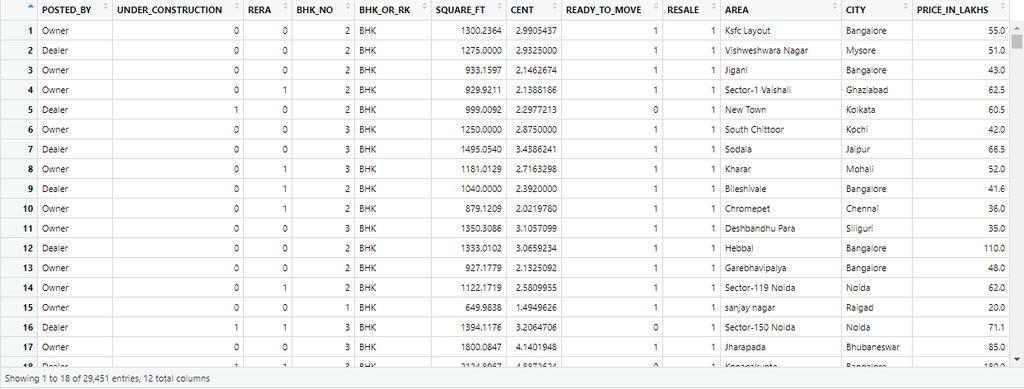

**Organizing Data:** Let us order the properties which are available for first time sale. Number 0 in RESALE indicates that the property is new and available in market for fresh sale.

```r
final %>%
  arrange(RESALE)
```

```
## # A tibble: 29,451 x 12
##    POSTED_BY UNDER_CONSTRUCTION  RERA BHK_NO BHK_OR_RK SQUARE_FT   CENT
##    <chr>                  <dbl> <dbl>  <dbl> <chr>         <dbl>  <dbl>
##  1 Dealer                     0     1      2 BHK            858.  1.97
##  2 Dealer                     1     1      1 BHK          40606. 93.4
##  3 Builder                    1     1      1 BHK            302.  0.694
##  4 Dealer                     1     1      1 BHK            406.  0.934
##  5 Dealer                     1     1      2 BHK            906.  2.08
##  6 Dealer                     1     1      4 BHK           1725.  3.97
##  7 Dealer                     1     1      4 BHK           1304.  3.00
##  8 Dealer                     1     1      2 BHK            500.  1.15
##  9 Dealer                     1     0      3 BHK           1846.  4.25
## 10 Dealer                     0     1      2 BHK           1500   3.45
## # i 29,441 more rows
## # i 5 more variables: READY_TO_MOVE <dbl>, RESALE <dbl>, AREA <chr>,
## #   CITY <chr>, PRICE_IN_LAKHS <dbl>
```

Summary statistics for numerical columns

```r
names(final)
```

```
##  [1] "POSTED_BY"          "UNDER_CONSTRUCTION" "RERA"
##  [4] "BHK_NO"             "BHK_OR_RK"          "SQUARE_FT"
##  [7] "CENT"               "READY_TO_MOVE"      "RESALE"
## [10] "AREA"               "CITY"               "PRICE_IN_LAKHS"
```

```r
summary(final[c("BHK_NO", "SQUARE_FT", "PRICE_IN_LAKHS")])
```

```
##      BHK_NO         SQUARE_FT         PRICE_IN_LAKHS
##  Min.   : 1.000   Min.   :        3   Min.   :    0.25
##  1st Qu.: 2.000   1st Qu.:      900   1st Qu.:   38.00
##  Median : 2.000   Median :     1175   Median :   62.00
##  Mean   : 2.392   Mean   :    19802   Mean   :  142.90
##  3rd Qu.: 3.000   3rd Qu.:     1551   3rd Qu.:  100.00
##  Max.   :20.000   Max.   :254545454   Max.   :30000.00
```

Counting frequency of attributes using table() function

```r
table(final$POSTED_BY) # Displays properties by who posted? and how many?
```

```
##
## Builder  Dealer   Owner
##     622   18291   10538
```

```r
table(final$UNDER_CONSTRUCTION) # 0 - Construction is over while 1 - Under construction
```

```
##
##     0     1
## 24157  5294
```

**Descriptive Statistical Analysis:**

1. Measures of central tendency: Mean, Median of numerical fields

```r
#group by BHK_NO and check price
BHK_Price <- final %>%
  group_by(BHK_NO) %>%
  summarise(
    average_price = mean(PRICE_IN_LAKHS),
    median_price = median(PRICE_IN_LAKHS),
    )
as.data.frame(BHK_Price)
```

```
##    BHK_NO average_price median_price
## 1       1      72.56343         32.9
## 2       2      97.17658         49.5
## 3       3     176.32942         80.0
## 4       4     350.82026        190.0
## 5       5     604.18789        340.0
## 6       6     868.84231        600.0
## 7       7    1387.59091        160.0
## 8       8     727.00000        375.0
## 9       9     213.33333        220.0
## 10     10     263.96250        227.5
## 11     11      55.00000         55.0
## 12     12     163.33333        180.0
## 13     13     500.00000        500.0
## 14     15     427.50000        390.0
## 15     17     320.00000        320.0
## 16     20     768.80000        530.0
```

2. Measures of dispersion: Inter Quartile Range, Variance, Standard Deviation of numerical attributes

```r
summary(final$PRICE_IN_LAKHS)
```

```
##     Min.  1st Qu.   Median     Mean  3rd Qu.     Max.
##     0.25    38.00    62.00   142.90   100.00 30000.00
```

```r
var(final$PRICE_IN_LAKHS)
```

```
## [1] 431492.3
```

```r
sd(final$PRICE_IN_LAKHS)
```

```
## [1] 656.8807
```

3. Measures of Symmetricity

```r
library(e1071)
skewness(final$PRICE_IN_LAKHS)
```

```
## [1] 17.58154
```

```r
kurtosis(final$PRICE_IN_LAKHS)
```

```
## [1] 451.827
```

**Relationship between features:** Correlation between Price and other numerical attributes

```r
cor(final$SQUARE_FT, final$PRICE_IN_LAKHS)
```

```
## [1] 0.4026846
```

```r
cor(final$BHK_NO, final$PRICE_IN_LAKHS)
```

```
## [1] 0.1122827
```

**Distribution of prices**

```r
# T-test for price differences between groups
t.test(PRICE_IN_LAKHS ~ READY_TO_MOVE, data = final)
```

```
##
##  Welch Two Sample t-test
##
## data:  PRICE_IN_LAKHS by READY_TO_MOVE
## t = 6.4808, df = 5937.6, p-value = 9.859e-11
## alternative hypothesis: true difference in means between group 0 and group 1 is not equal to 0
## 95 percent confidence interval:
##   66.10309 123.43660
## sample estimates:
## mean in group 0 mean in group 1
##        220.6331        125.8633
```

**Home buyer preferences:** BHK vs RK

```r
BHK_over_RK <- final %>%
  group_by(BHK_OR_RK) %>%
  count() %>%
  pivot_wider(names_from = BHK_OR_RK, values_from = n) %>%
  mutate(prop_BHK = BHK / (BHK + RK))
BHK_over_RK
```

```
## # A tibble: 1 x 3
##     BHK    RK prop_BHK
##   <int> <int>    <dbl>
## 1 29427    24    0.999
```

**Comparing** prices of *RERA Approved* vs *Not Approved* properties.

```r
RERA_PRICE <- final %>%
  group_by(RERA) %>%
  summarise( PRICE = mean(PRICE_IN_LAKHS))
RERA_PRICE  # 0 - Not Approved; 1 - Approved
```

```
## # A tibble: 2 x 2
##    RERA PRICE
##   <dbl> <dbl>
## 1     0  113.
## 2     1  208.
```

**Top 5 cities** preferred by home buyers in India

```r
demand_by_location <- final %>%
  group_by(CITY) %>%
  count(sort = TRUE)
head(demand_by_location, 5)
```

```
## # A tibble: 5 x 2
## # Groups:   CITY [5]
##   CITY          n
##   <chr>     <int>
## 1 Bangalore  4340
## 2 Lalitpur   2993
## 3 Mumbai     2023
## 4 Pune       1991
## 5 Noida      1767
```

```r
# Filter for RERA approved and ready-to-move properties
approved_ready_to_move <- final %>%
  filter(RERA == 1 & READY_TO_MOVE == 1)

# Sort by cent
approved_ready_to_move <- approved_ready_to_move %>%
  arrange(CENT)

# List cent and price
summary(approved_ready_to_move[c("BHK_NO", "SQUARE_FT", "PRICE_IN_LAKHS")])
```

```
##      BHK_NO        SQUARE_FT        PRICE_IN_LAKHS
##  Min.   :1.000   Min.   :   221.7   Min.   :   1.00
##  1st Qu.:2.000   1st Qu.:   988.0   1st Qu.:  44.38
##  Median :2.000   Median :  1263.5   Median :  72.00
##  Mean   :2.472   Mean   :  2020.0   Mean   : 170.83
##  3rd Qu.:3.000   3rd Qu.:  1680.7   3rd Qu.: 130.00
##  Max.   :7.000   Max.   :174909.1   Max.   :9800.00
```

```r
head(approved_ready_to_move[c("BHK_NO", "SQUARE_FT", "PRICE_IN_LAKHS")])
```

```
## # A tibble: 6 x 3
##   BHK_NO SQUARE_FT PRICE_IN_LAKHS
##    <dbl>     <dbl>          <dbl>
## 1      1      222.           10.4
## 2      1      226.            4.5
## 3      1      226.            4.5
## 4      1      226.            4.5
## 5      1      290.           46
## 6      1      290.           46
```

### 6. Share

This phase involves making this work accessible to audience by presenting insights found through the art of visualization.

**Data Visualization:**

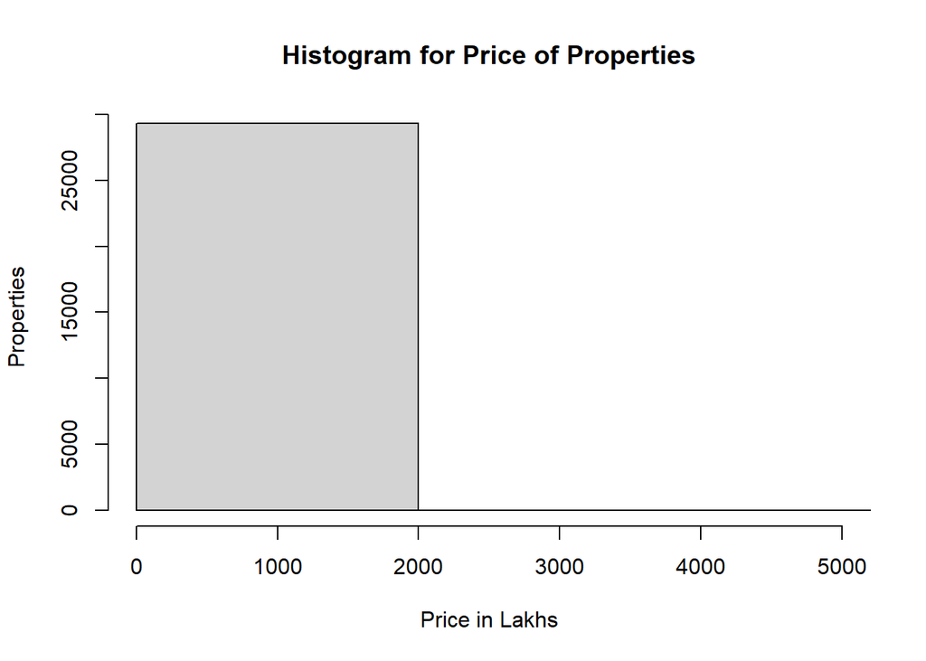

```r
hist(final$PRICE_IN_LAKHS, xlab = "Price in Lakhs", ylab = "Properties", xlim = c(0,5000), main = paste("Histogram for" , "Price of Properties")) #
```

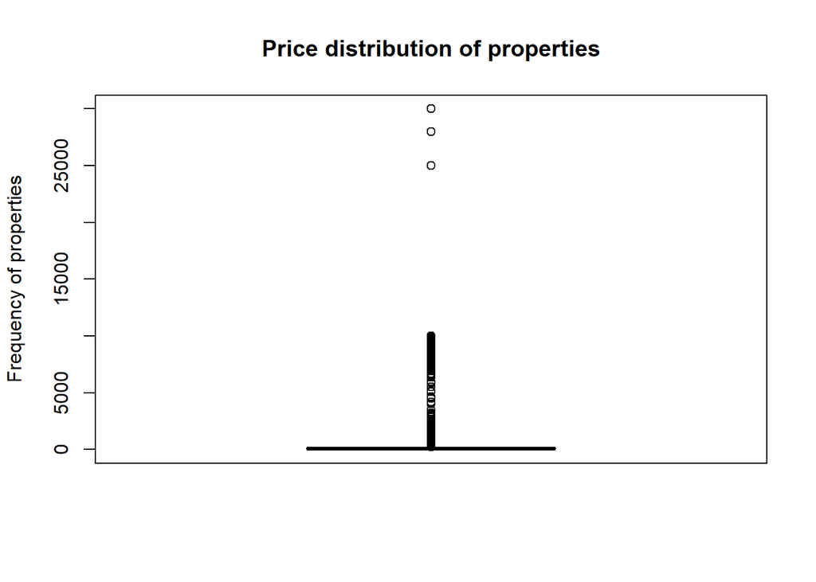

```r
boxplot(final$PRICE_IN_LAKHS, ylab = "Frequency of properties", main = "Price distribution of properties") # Used for outlier detection: 3 data points lies far apart from others.
```

**Bar plot for categorical variables:**

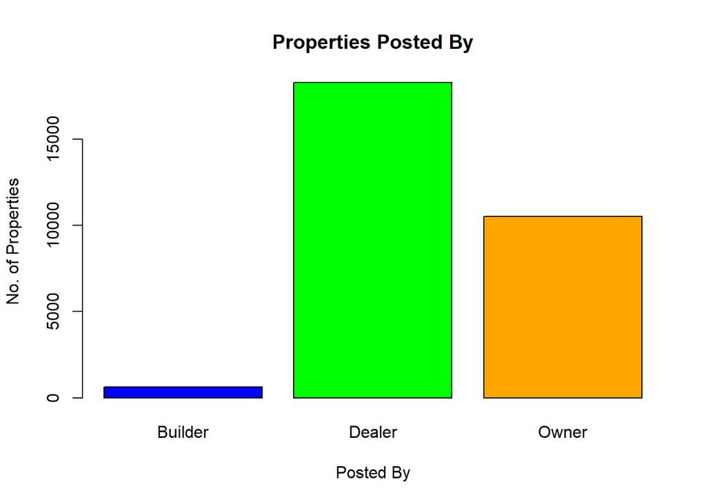

```r
barplot(table(final$POSTED_BY), xlab = "Posted By", ylab = "No. of Properties", main = "Properties Posted By", col = c("blue", "green", "orange"))
```

**Scatter plot for numerical relationships:**

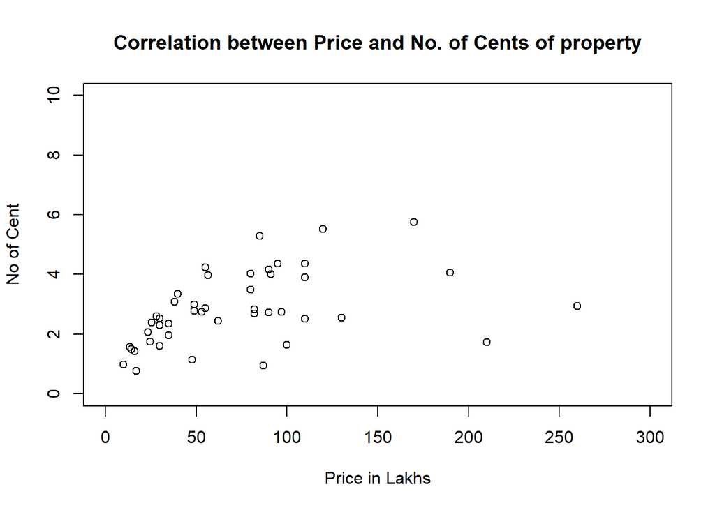

```r
pd <- final[sample(nrow(final), 50), ]

plot(x = pd$PRICE_IN_LAKHS, y = pd$CENT, xlab = "Price in Lakhs", ylab = "No of Cent", xlim = c(0, 300), ylim =c(0, 10), main = "Correlation between Price and No. of Cents of property")
```

**Box plots for price comparisons by construction status:**

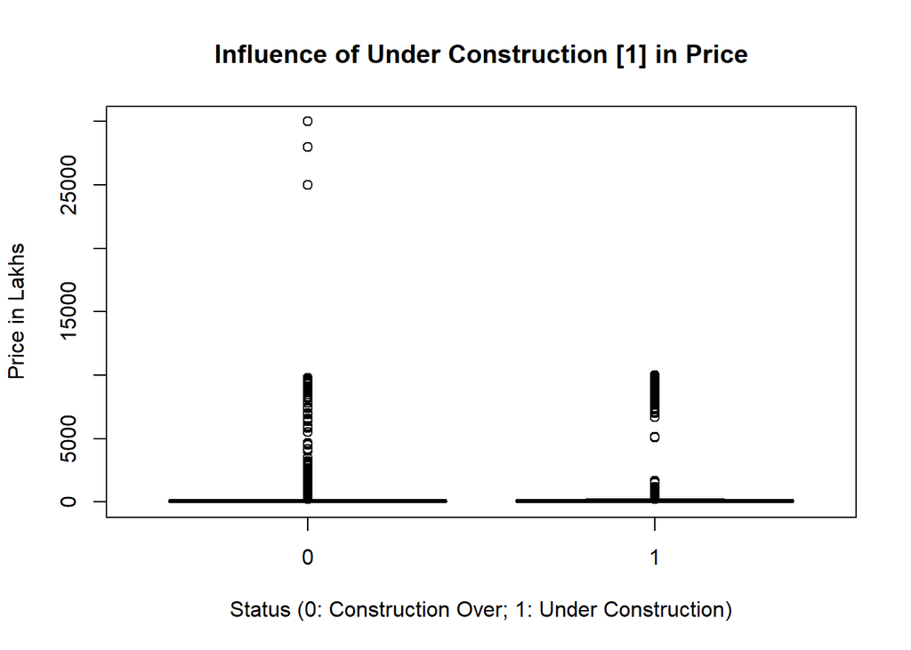

```r
boxplot(PRICE_IN_LAKHS ~ UNDER_CONSTRUCTION, data = final, ylab = "Price in Lakhs", xlab = "Status (0: Construction Over; 1: Under Construction)", main = "Influence of Under Construction [1] in Price", col = "blue")
```

**Bar chart for REAR Approved & Not Approved price comparison:**

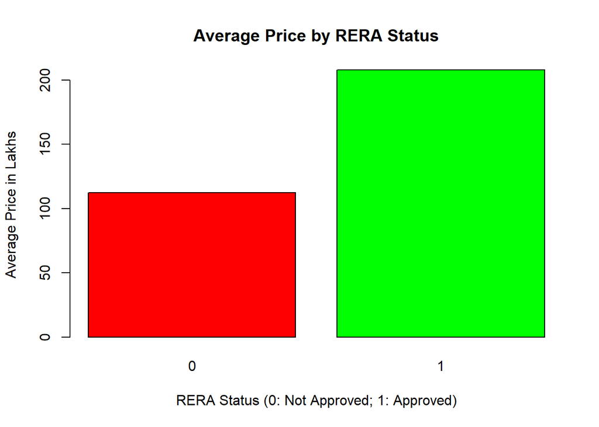

```r
barplot(RERA_PRICE$PRICE, names.arg = RERA_PRICE$RERA, col = c("red", "green"),
        xlab = "RERA Status (0: Not Approved; 1: Approved)", ylab = "Average Price in Lakhs", main = "Average Price by RERA Status")
```

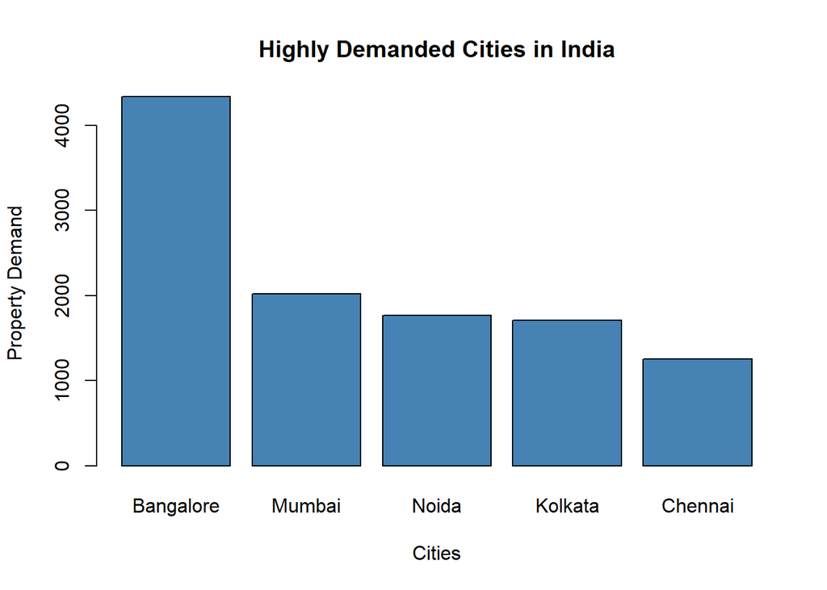

```r
selected_cities_state <- c("Bangalore", "Chennai", "Mumbai","Kolkata", "Noida")
data_subset1 <- demand_by_location[demand_by_location$CITY %in% selected_cities_state, ]

barplot(data_subset1$n, names.arg = data_subset1$CITY, col = "steelblue",
        xlab = "Cities", ylab = "Property Demand", main = "Highly Demanded Cities in India")
```

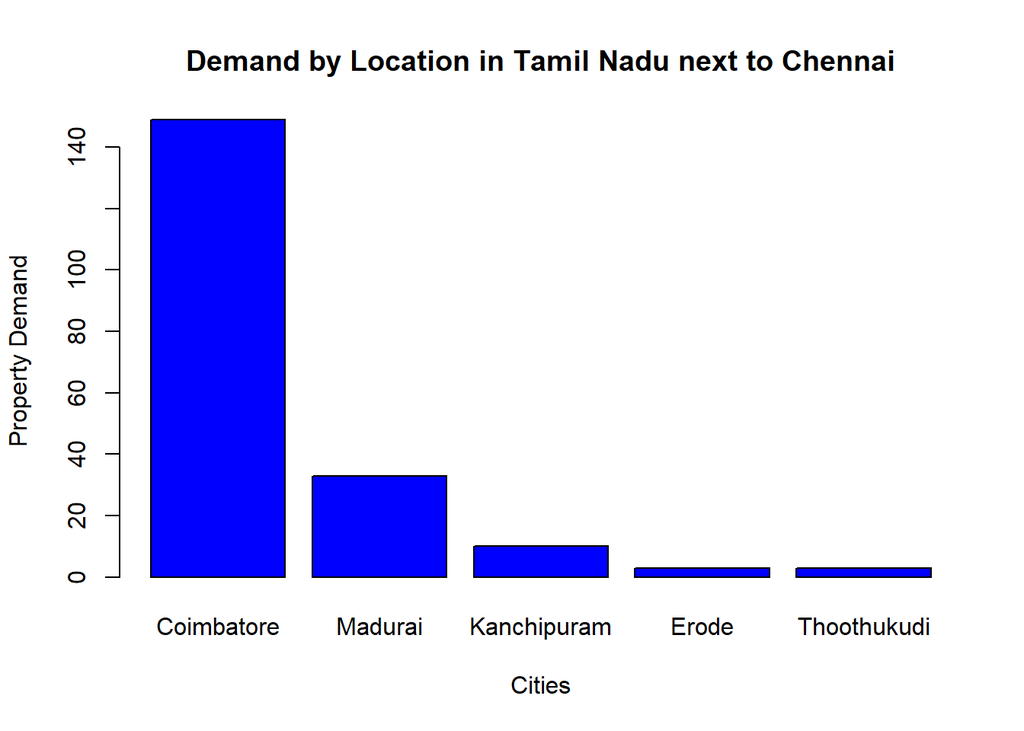

```r
selected_cities <- c("Coimbatore", "Madurai", "Kanchipuram", "Erode", "Thoothukudi")
data_subset2 <- demand_by_location[demand_by_location$CITY %in% selected_cities, ]

barplot(data_subset2$n, names.arg = data_subset2$CITY, col = "blue",
        xlab = "Cities", ylab = "Property Demand", main = "Demand by Location in Tamil Nadu next to Chennai")
```

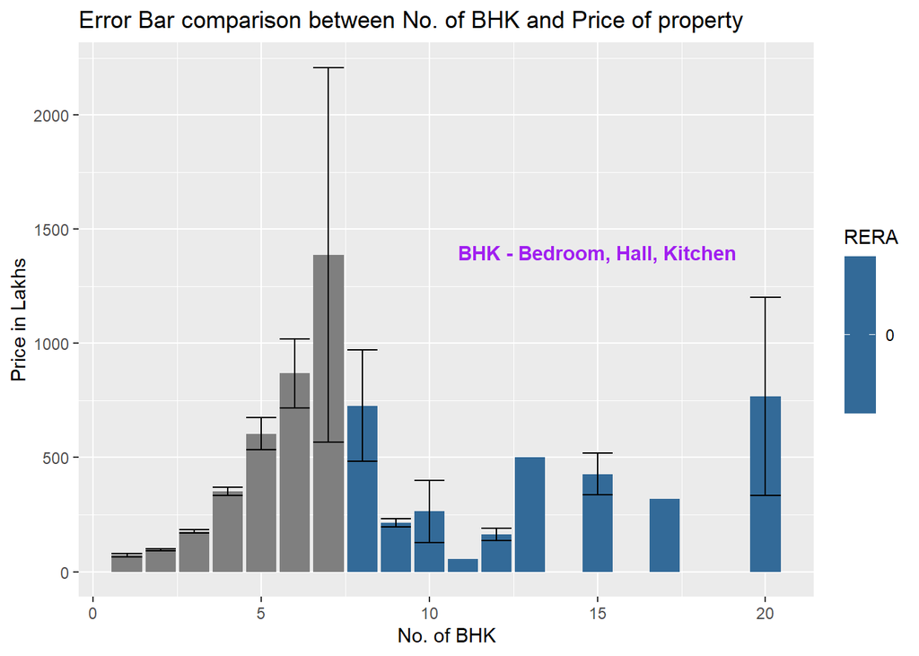

```r
ggplot(final, aes(x = BHK_NO, y = PRICE_IN_LAKHS, fill = RERA)) +
  geom_bar(stat = "summary", fun = "mean") +
  geom_errorbar(stat = "summary", fun.data = "mean_se") +
  ggtitle("Error Bar comparison between No. of BHK and Price of property ") +
  labs(x = "No. of BHK", y = "Price in Lakhs") +
  annotate("text", x = 15, y = 1400, label = "BHK - Bedroom, Hall, Kitchen", color = "purple", fontface = "bold")
```

Let us filter the properties which are approved and ready to move as well less then or equal to 10 Crore and start visualizing them.

```r
library(dplyr)
data_filtered <- approved_ready_to_move %>%
  filter(PRICE_IN_LAKHS <= 1000)
data_filtered
```

```
## # A tibble: 5,698 x 12
##    POSTED_BY UNDER_CONSTRUCTION  RERA BHK_NO BHK_OR_RK SQUARE_FT  CENT
##    <chr>                  <dbl> <dbl>  <dbl> <chr>         <dbl> <dbl>
##  1 Builder                    0     1      1 RK             222. 0.510
##  2 Dealer                     0     1      1 BHK            226. 0.519
##  3 Dealer                     0     1      1 BHK            226. 0.519
##  4 Dealer                     0     1      1 BHK            226. 0.519
##  5 Dealer                     0     1      1 BHK            290. 0.667
##  6 Dealer                     0     1      1 BHK            290. 0.667
##  7 Dealer                     0     1      1 BHK            297. 0.683
##  8 Dealer                     0     1      1 BHK            297. 0.683
##  9 Dealer                     0     1      1 BHK            297. 0.683
## 10 Dealer                     0     1      1 BHK            297. 0.683
## # i 5,688 more rows
## # i 5 more variables: READY_TO_MOVE <dbl>, RESALE <dbl>, AREA <chr>,
## #   CITY <chr>, PRICE_IN_LAKHS <dbl>
```

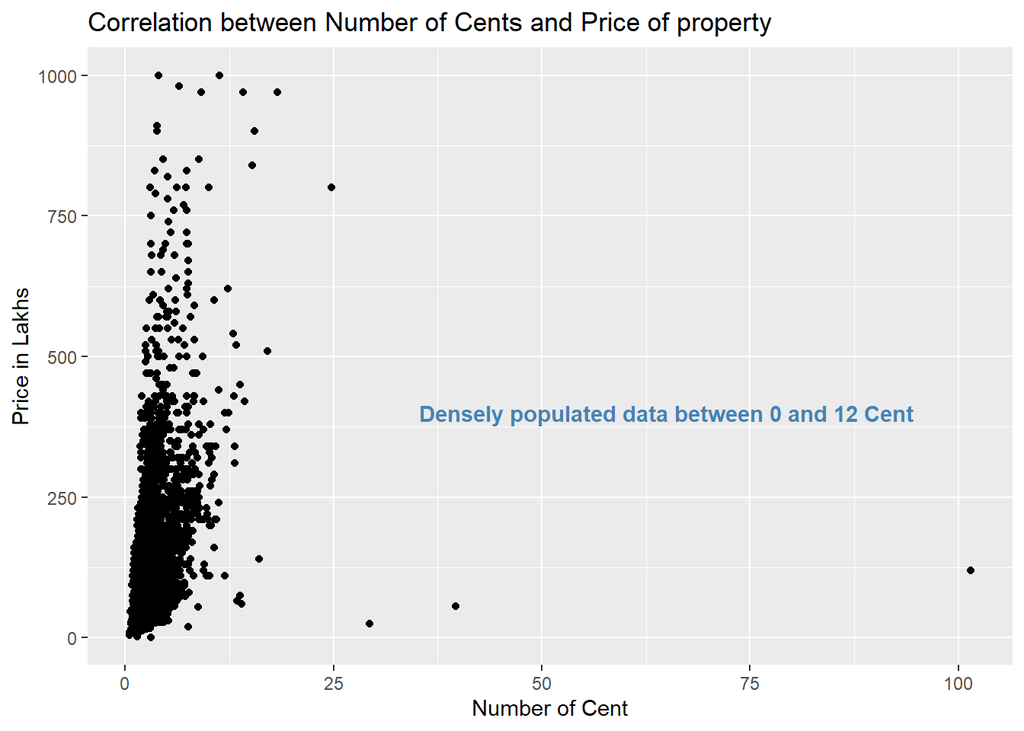

```r
ggplot(data=data_filtered) +
  geom_point(mapping = aes(x = CENT, y = PRICE_IN_LAKHS)) +
  ggtitle("Correlation between Number of Cents and Price of property ") +
  labs(x = "Number of Cent", y = "Price in Lakhs") +
  annotate("text", x = 65, y = 400, label = "Densely populated data between 0 and 12 Cent", color = "steelblue", fontface = "bold")
```

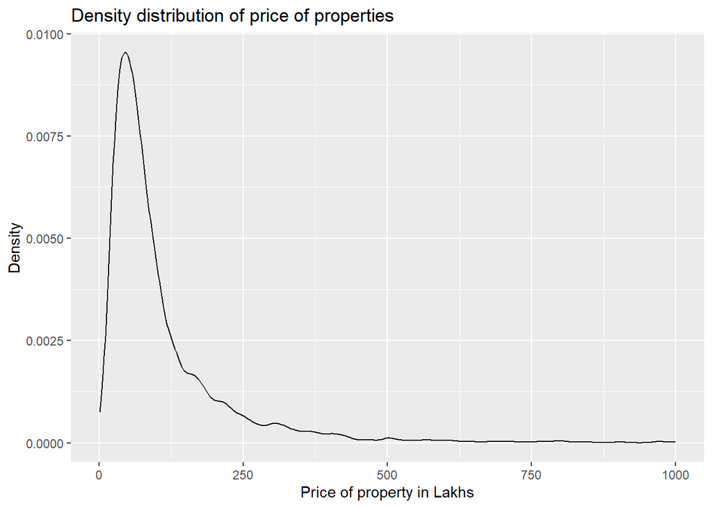

```r
ggplot(data_filtered, aes(x = PRICE_IN_LAKHS)) +
  geom_density() +
  ggtitle("Density distribution of price of properties") +
  labs(x = "Price of property in Lakhs", y = "Density")
```

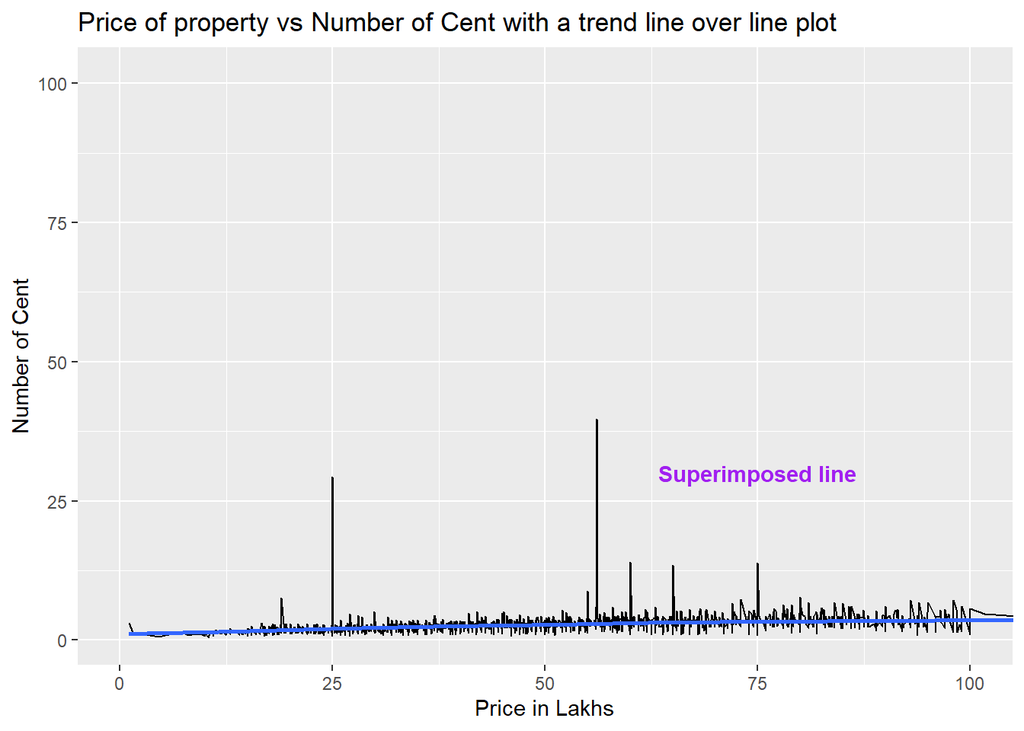

```r
ggplot(data_filtered, aes(x = PRICE_IN_LAKHS, y = CENT)) +
  geom_line() +
  geom_smooth() +
  coord_cartesian(xlim = c(0,100)) +
  annotate("text", x = 75, y = 30, label = "Superimposed line", color = "purple", fontface = "bold") +
  ggtitle("\tPrice of property vs Number of Cent with a trend line over line plot") +
  labs(x = "Price in Lakhs", y = "Number of Cent")
```

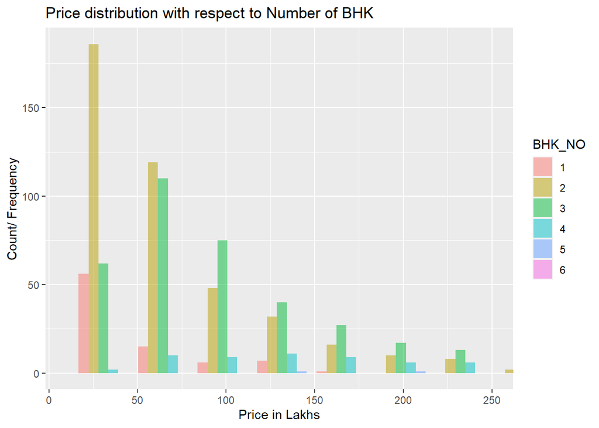

```r
ggplot(data_filtered[sample(nrow(data_filtered), 1000), ], aes(x = PRICE_IN_LAKHS, fill = factor(BHK_NO))) +
  geom_histogram(alpha = 0.5, position = "dodge") +
  labs(x = "Price in Lakhs", fill = "BHK_NO", y = "Count/ Frequency") +
  ggtitle("Price distribution with respect to Number of BHK") +
  coord_cartesian(xlim = c(10,250) )
```

**Purpose of Violin Plot:**

Visually display the distribution of a numerical variable across different categories or groups.

*Highlights:*

- Central tendency like mean,median can be computed
- Spread and variability like interquartile range, density can be calculated
- Asymmetry (skewness) of distribution
- Presence of outliers can be detected

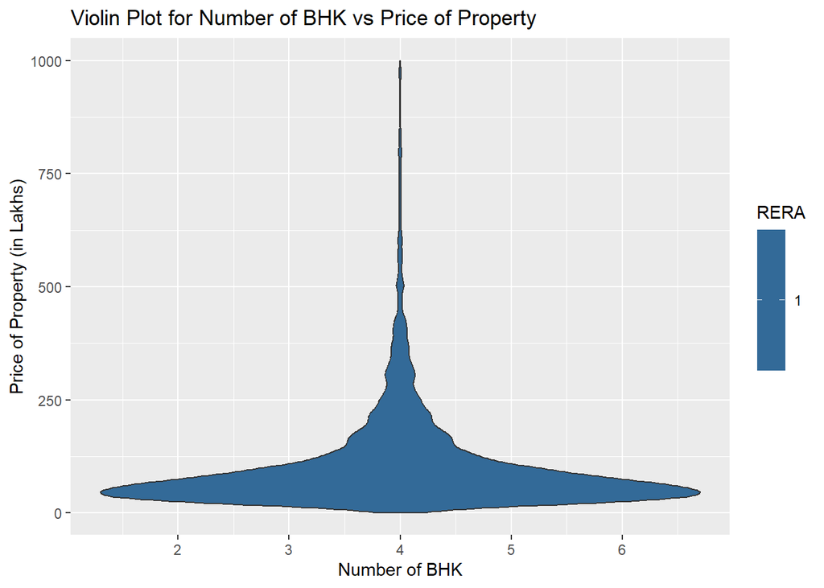

```r
ggplot(data_filtered[sample(nrow(data_filtered), ), ], aes(x = BHK_NO, y = PRICE_IN_LAKHS, fill = RERA)) +
  geom_violin() +
  ggtitle("Violin Plot for Number of BHK vs Price of Property") +
  labs(x = "Number of BHK", y = "Price of Property (in Lakhs)")
```

### 7. Act

This analysis provides valuable insights for stakeholders in the Indian housing market, including builders, developers, and real estate agents, to make informed decisions:

##### **Insights Gained:**

**3. Targeted Marketing:**

- *Develop Location-Specific Campaigns:* Customize marketing messages and communication channels for different cities based on local preferences.